# Chapter03

## 3. “Data visualisation” [Chapter 1 hardcopy]

### 3.7.1 Exercises

Q1. What is the default geom associated with stat_summary()? How could you rewrite the previous plot to use that geom function instead of the stat function?

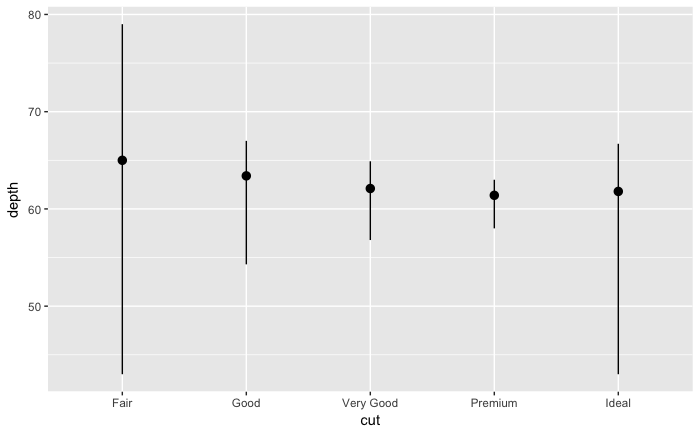

```r
?stat_summary
?geom_pointrange
ggplot(data = diamonds) +
  stat_summary(mapping = aes(x = cut, y = depth), fun.ymin = min, fun.ymax = max, fun.y = median)
```

A1. Default geom for stat_summary is geom_pointrange. But default stat for geom_pointrange is identity, so use `geom_pointrange(stat = "summary")`

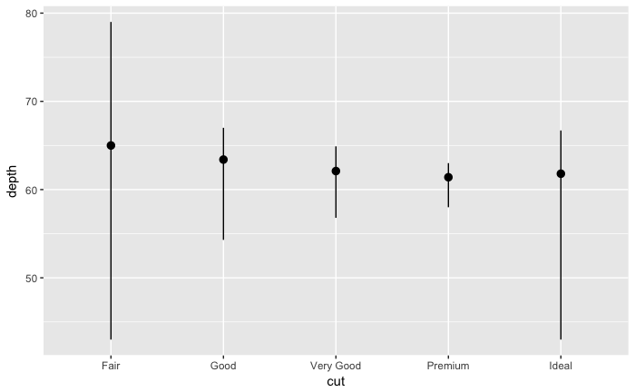

```r
ggplot(data = diamonds) +
  geom_pointrange(mapping = aes(x = cut, y = depth), stat = "summary", fun.ymin = min, fun.ymax = max, fun.y = median)
```

Q2. What does geom_col() do? How is it different to geom_bar()?

```r
?geom_col
?geom_bar
```

A2. “geom_bar uses stat_count by default: it counts the number of cases at each x position. geom_col uses stat_identity: it leaves the data as is” geom_bar(stat = “identity”) and geom_col() are equivalent

Q3. Most geoms and stats come in pairs that are almost always used in concert Read through the documentation and make a list of all the pairs. What do they have in common?

A3. http://ggplot2.tidyverse.org/reference/ ?

Q4. What variables does stat_smooth() compute? What parameters control its behaviour?

```r
?stat_smooth
```

A4. Four : y [predicted value]; ymin [lower pointwise confidence interval around the mean]; ymax [upper pointwise confidence interval around the mean]; se [standard error] Most importantly : method [smoothing method (function) to use]; se [whether to display confidence interval]; level [level of confidence interval to use (0.95 default)]

Q5. In our proportion bar chart, we need to set group = 1. Why? In other words what is the problem with these two graphs?

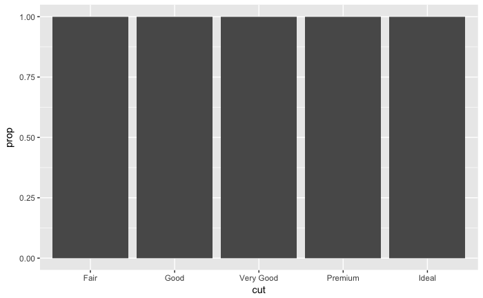

```r
ggplot(data = diamonds) +
  geom_bar(mapping = aes(x = cut, y = ..prop..)) # 'prop' is 1.00 for each value of 'cut'
```

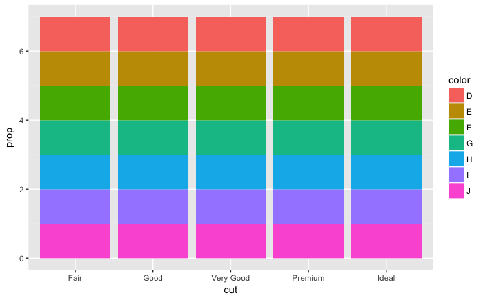

```r
ggplot(data = diamonds) +
  geom_bar(mapping = aes(x = cut, fill = color, y = ..prop..)) # 'prop' is 7 for each value of 'cut' (7 colors)
```

A5. We’ve relied on other variables to change aggregation (eg. color = drv instead of a separate group = drv) cf. s3.6 : “It is convenient to rely on this feature because the group aesthetic by itself does not add a legend or distinguishing features to the geoms” But ‘..prop..’ means proportion of group, and that will be 100% unless we force it otherwise group=1 means everything is in the same group (named ‘1’), rather than in different groups (named Fair, Good, etc …if group=cut) …Imagine a field called ‘group’, where every row has the value ‘1’ there group=2 or group=X would have the same effect. (Don’t know why it has to be inside aes(), since it’s a constant)

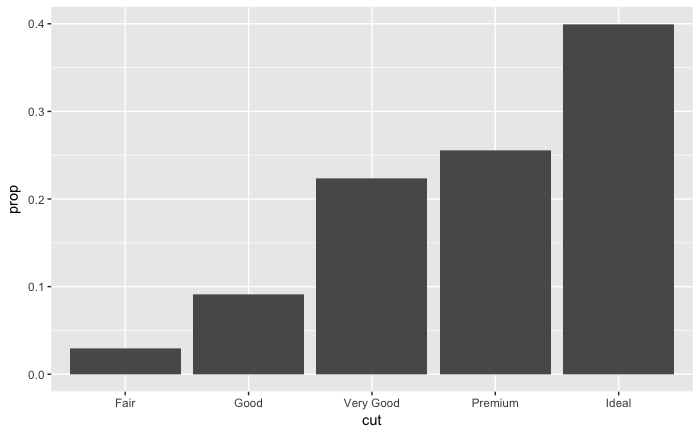

```r
ggplot(data = diamonds) +
  geom_bar(mapping = aes(x = cut, y = ..prop.., group = 1))
```

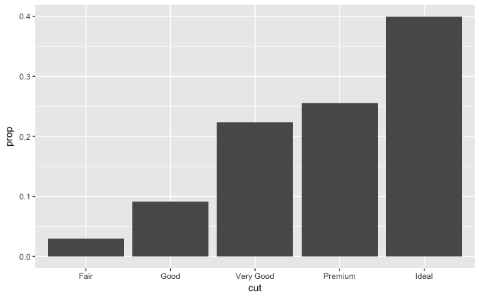

```r
ggplot(data = diamonds) +
  geom_bar(mapping = aes(x = cut, fill = color, y = ..prop.., group = 1)) # Why isn't chart coloured?
```

## 3. “Data visualisation” [Chapter 1 hardcopy]

### 3.8.1 Exercises

Q1. What is the problem with this plot? How could you improve it?

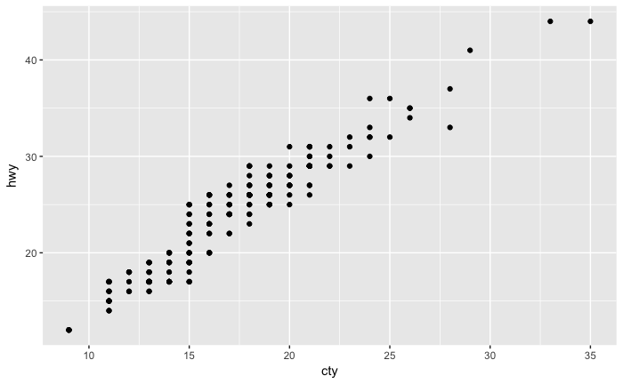

A1. Many of the data points overlap (overplotting). We can jitter the points, to improve the overall visualization (in this case)

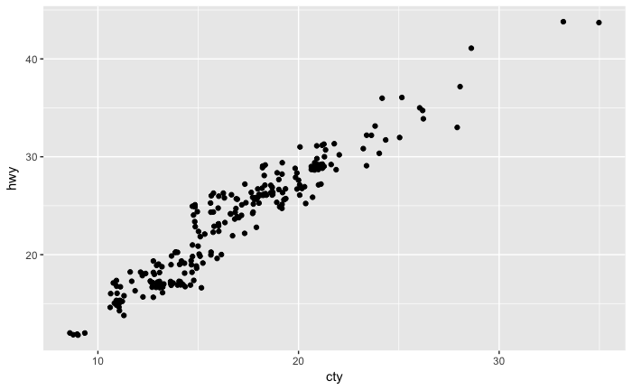

Q2. What parameters to geom_jitter() control the amount of jittering?

```r
?geom_jitter
```

A2. width and height

Q3. Compare and contrast geom_jitter() with geom_count()

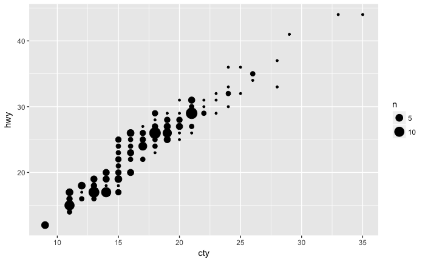

A3. “This is a variant geom_point that counts the number of observations at each location, then maps the count to point area” It makes larger points where there is overplotting, so the number of visible points is equal to geom_point()

Q4. What’s the default position adjustment for geom_boxplot()? Create a visualisation of the mpg dataset that demonstrates it

```r
?geom_boxplot
```

A4. position = “dodge” is the default

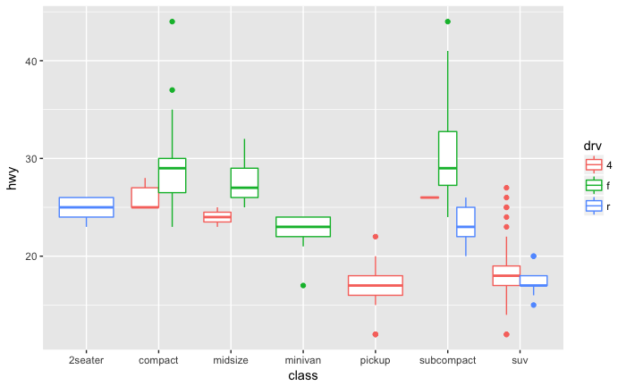

## 3. “Data visualisation” [Chapter 1 hardcopy]

### 3.9.1 Exercises

Q1. Turn a stacked bar chart into a pie chart using coord_polar()

A1.

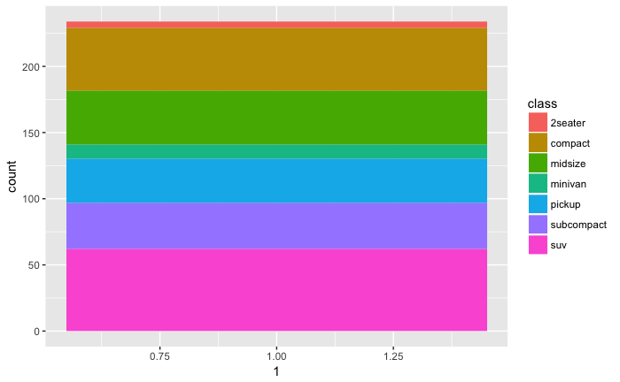

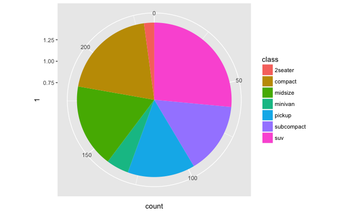

Q2. What does labs() do? Read the documentation

```r
?labs
```

A2. labs is a shortcut function to add labels to different scales …title, subtitle, axes, and caption

Q3. What’s the difference between coord_quickmap() and coord_map()?

```r
?coord_map
```

A3. “coord_quickmap() sets the aspect ratio correctly for maps” – R4DS text “coord_map projects a portion of the earth, which is approximately spherical, onto a flat 2D plane using any projection defined by the mapproj package. Map projections do not, in general, preserve straight lines, so this requires considerable computation. coord_quickmap is a quick approximation that does preserve straight lines. It works best for smaller areas closer to the equator”

Q4. What does the plot below tell you about the relationship between city and highway mpg? Why is coord_fixed() important? What does geom_abline() do?

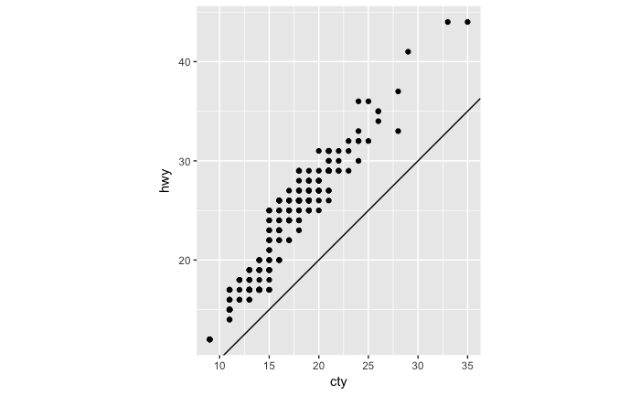

A4. Relationship is positive and approximately linear. Slightly better highway mpg than city mpg

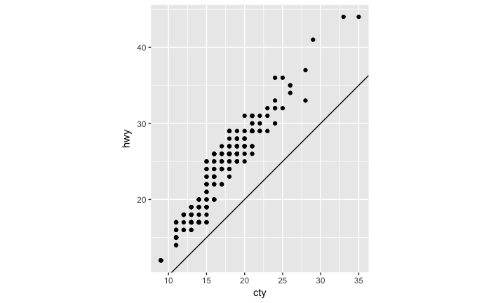

Comment & code from @aaron_g in (R4DS Slack) board=02_week on 15/9/17 06:25, in reply to query from @darh78 Not one of the exercises, but saved here in case useful in future. (Slope charts in a lattice) “i think this kind of graph is much more informative (maybe this is what you had in mind to begin with)”

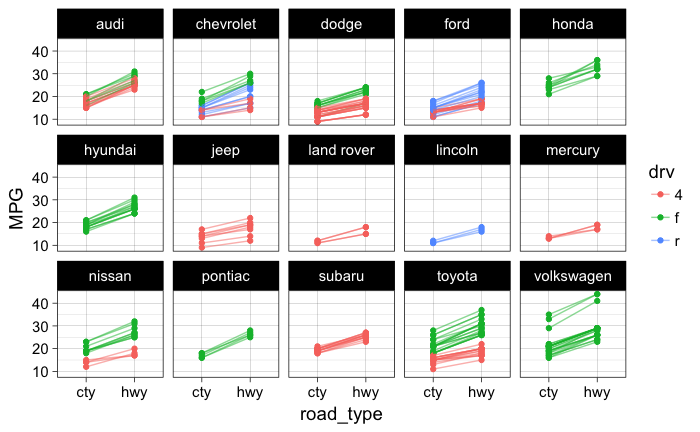

```r
mpg1 <- mpg %>%
  mutate(unique = rownames(mpg)) %>%
  gather("road_type" ,"MPG", c("cty", "hwy"))
ggplot(data = mpg1,mapping = aes(x = road_type, y = MPG, color=drv ,group=unique)) +
  geom_point() +
  facet_wrap(~manufacturer, nrow=3)+
  geom_line(alpha=0.5) +
  theme_linedraw(base_size = 14)
```